# Actitudes hacia la inmigración en Europa

M8 · Visualización de datos y Reproducibilidad · Reto 2

## El problema

Un **observatorio de migraciones europeo**, investigadores, analistas de datos, y profesionales en comunicación, necesitan responder de forma rápida y auditable a preguntas recurrentes sobre la opinión pública ante la inmigración.

**Objetivo principal**

> Describir y comparar la evolución de las actitudes hacia la inmigración en catorce países europeos a lo largo de dos décadas, identificando los patrones comunes, las divergencias nacionales y los segmentos de población que las sustentan.

**Objetivos específicos**

1. Situar la trayectoria de cada país en el contexto europeo.
2. Determinar si el conjunto converge o diverge.
3. Caracterizar los segmentos sociodemográficos asociados a cada posición.
4. Establecer el vínculo con indicadores más amplios de cohesión social.

## Los datos

**Encuesta Social Europea (ESS)**, rondas 1 a 11, campo 2002 – 2023/24.

- Extracto propio de **290.398 entrevistas** y 49 variables.
- **14 países**: solo los presentes en las once rondas, de modo que la matriz país × ronda no tiene huecos.
- Índice de actitud (0–10) construido con tres ítems, α = 0,844; 271.544 entrevistas con índice calculable.

**Decisiones de depuración**

1. El peso `anweight` **falta al 100% en las rondas 2 y 3**. Se reconstruye como `pspwght × pweight`, definición del propio ESS verificada en las nueve rondas donde ambos coexisten. Sin ella se perderían 53.442 casos.
2. El año de entrevista falta en cuatro rondas: el eje temporal se deriva de `essround`. El intervalo **no es regular**, así que el año se trata como escala cuantitativa.
3. Toda media va **ponderada**, sin excepción.

## Los números de partida

5,72

Media europea 2023  
(índice 0–10)

+0,48

Cambio desde 2002  
(puntos)

2,71

Amplitud entre países  
(máximo − mínimo)

Europa se abre, pero **no toda a la vez**: la media sube 0,48 puntos mientras la distancia entre el país más abierto y el más restrictivo se ensancha hasta 2,71 puntos.

## Tabla resumen · los siete países que más avanzan

```r
kable(head(tabla, 7), digits = 2, format.args = list(decimal.mark = ","))
```

| País | 2002 | 2023 | Cambio | Gradiente educativo | ρ actitud–confianza |
| --- | --- | --- | --- | --- | --- |
| Irlanda | 5,33 | 6,28 | 0,94 | 1,52 | 0,88 |
| Portugal | 4,60 | 5,51 | 0,92 | 1,23 | 0,55 |
| Noruega | 5,32 | 6,19 | 0,87 | 1,08 | 0,91 |
| España | 5,38 | 6,22 | 0,83 | 1,15 | -0,37 |
| Bélgica | 4,85 | 5,65 | 0,80 | 1,15 | 0,70 |
| Países Bajos | 5,20 | 5,80 | 0,60 | 1,03 | 0,85 |
| Eslovenia | 4,64 | 5,18 | 0,54 | 1,51 | 0,31 |

Ordenados por la variación entre 2002 y 2023. Encabeza la tabla **Irlanda**, con 0,94 puntos de mejora.

## Tabla resumen · los siete restantes

| País | 2002 | 2023 | Cambio | Gradiente educativo | ρ actitud–confianza |
| --- | --- | --- | --- | --- | --- |
| Finlandia | 5,97 | 6,49 | 0,53 | 0,95 | 0,77 |
| Suiza | 5,77 | 6,23 | 0,46 | 1,02 | 0,85 |
| Francia | 4,94 | 5,32 | 0,38 | 1,59 | 0,55 |
| Polonia | 5,32 | 5,53 | 0,21 | 0,84 | -0,27 |
| Alemania | 5,36 | 5,53 | 0,18 | 1,15 | 0,84 |
| Suecia | 6,33 | 6,36 | 0,03 | 1,16 | 0,95 |
| Hungría | 4,42 | 3,78 | -0,64 | 0,98 | -0,39 |

Cierra la tabla **Hungría**, el único país que retrocede (-0,64 puntos). Aun así su gradiente educativo sigue siendo positivo, igual que en los otros trece.

## ¿Cómo ha evolucionado cada país?

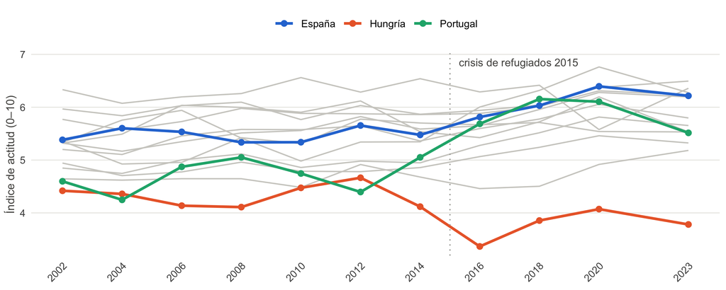

13 de los catorce países mejoran. **Hungría es la única excepción**: cae de 4,42 a 3,78, con un descenso de 0,75 puntos concentrado entre 2014 y 2016, justo tras la crisis de refugiados.

## ¿Convergen o divergen? Divergen

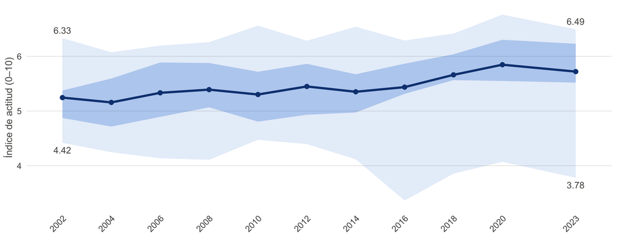

La banda se ensancha: la desviación típica entre las medias nacionales pasa de 0,537 a 0,701. **El promedio europeo esconde trayectorias que se separan**, así que leer solo la media agregada sería engañoso.

## ¿Qué perfil se asocia a una actitud favorable?

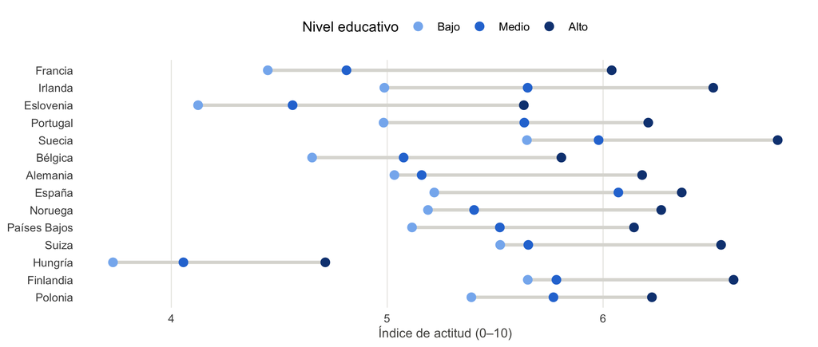

El gradiente educativo es **monótono en los 14 países**: varía entre 0,84 puntos en Polonia y 1,59 en Francia. Es la asociación mejor sustentada del análisis.

## Dos detalles

**Valorar bien la inmigración no es querer admitir más.** Los dos índices miden constructos distintos y a nivel de país correlacionan solo ρ = 0,591. Finlandia ocupa el puesto 2 de 14 en valoración pero el 12 en permisividad. Alemania presenta el patrón inverso (9 y 3).

**El rechazo no acompaña siempre a la desafección institucional.** La correlación temporal entre actitud y confianza institucional va desde 0,95 en Suecia hasta -0,39 en Hungría; en 3 de los catorce países es **negativa**. No hay un patrón europeo único, y por eso esta pregunta se responde en la vista de exploración del dashboard. Es demasiado compleja para una pantalla de resumen.

## El dashboard

**Dos vistas**, siguiendo el mantra de Shneiderman: panorámica primero, zoom y filtrado, detalle bajo demanda.

**Dos aspectos importantes**

- **Cada país conserva su color** en los dos paneles y bajo cualquier filtro: el color acompaña a la entidad, nunca a su posición en el orden.
- Ninguna información se transmite solo por color; la etiqueta emergente nombra siempre el país y añade el **tamaño muestral** de la celda, que es lo que permite juzgar si una diferencia de tres décimas significa algo.

## Reproducibilidad

```
01_importar_depurar.R   ->  ess_clean.rds
02_eda.R                ->  figuras (.png) y tablas agregadas (.csv)
dashboard.Rmd | informe.Rmd | presentacion.Rmd
```

- **Ninguna ruta absoluta**: todas se construyen con `here`, anclado en `m8_reto2.Rproj`.
- El dashboard, el informe y esta presentación **leen las mismas tablas agregadas** y no recalculan ninguna media: no pueden discrepar entre sí.
- Todas las cifras de estas diapositivas están insertadas mediante código en línea, no escritas a mano.
- Las ediciones y los DOI de cada ronda del ESS quedan fijados en el README, porque los ficheros del ESS se reeditan de forma continua.

**Límites del alcance**: 14 de los más de 30 países del ESS; la ronda 10 de cuatro países se recogió por autocumplimentación y muestra un posible efecto de modo; el diseño es transversal repetido, así que describe poblaciones, no individuos, y ninguna asociación admite lectura causal.

## ¡Muchas gracias!

**Repositorio**: todo el código, los datos y las salidas compiladas.

Encuesta Social Europea (ESS), rondas 1–11 · https://ess.sikt.no

Compilado con R Markdown y knitr el 2 de septiembre de 2026.